# TP2 - Stats

## Exercise 1 - defective test

The company SupGlass manufactures glass tiles which are used by another factory, a subsidiary of SupGlass According to the Quality assurance department, the proportion of defective glass tiles is 5%

1. What is the probability that the 4th glass tile tested is the first defective?
2. How many slabs do you have to check, on average, to observe the first defective tile

Si j’effectue une fois l’expérience, pour un échantillon trop petit je n’observerai pas à chaque l’évenement rare.

If we do the experience once with 20 then 5000 glasses (with the random seed fixed at 456) there are no defects with 20 glasses and 250 (5%) defect with 5000 glasses.

```r
set.seed(456)
s <- sample(x = c("D", "ND"), size = 20, replace = TRUE, prob = c(0.05, 1-0.05) )
table(s)
```

```
## s
## ND
## 20
```

```r
s2 <- sample(x = c("D", "ND"), size = 5000, replace = TRUE, prob = c(0.05, 1-0.05) )
table(s2)
```

```
## s2
##    D   ND
##  250 4750
```

```r
set.seed(456)
n <- 1000
sv <- rep(0, n)
for(i in 1:n){
        s <- sample(x = c("D", "ND"), size = 20, replace = TRUE, prob = c(0.05, 1-0.05) )
        sv[i] <- sum(s == "D")
}
table(sv)
```

```
## sv
##   0   1   2   3   4   5
## 343 387 179  73  17   1
```

```r
mean(sv)
```

```
## [1] 1.037
```

```r
sd(sv)
```

```
## [1] 0.9912687
```

## Exercise 2 - activity poll

360 people were asked what their favorite activity was between reading, cinema and sports.

[output not shown]

1 / Complete the table below

Compléter le tableau ci-dessous

```r
library(tibble)
total <- 360
total_men <- 0.6*total
total_women <- total - total_men
act <- tibble("activity" = c("cinema", "sport", "reading"),
              "men" = c(0.25*total_men, 0.5*total_men, 0.25*total_men),
              "women" = c(0.5*total_women, 1/6*total_women, 1/3*total_women)
              )
knitr::kable(act)
```

[output not shown]

In the rest of the exercise, the answers will be given in the form of irreducible fractions. We note the events prefer Sport, Reading, Cinema respectively S, R and C We note the events of being a Male M and being a Female F.

2 / One of these people is questioned at random. Complete :

$$ P(M) =

P (C) =

P(M∩R) =

P(FUR) = $$

3 / a) We interview a Man, the probability that he prefers Cinema is

2. We ask someone who prefers cinema, the probability that it will be a man is
3. We interview someone who does not like reading, the probability that it is a woman is

## Exercise 3 - stats on specific field

Specify the population, the trait and the nature of the trait (qualitative or quantitative), when considering: a) The amount of the annual salary of the employees of a company b) The size of the students of an MSc2 class c) The color of the teddy bears d) Age of members of the National Assembly

## Exercise 4 - MSc1 stats

A teacher questions the 35 students of an MSc1 class about the number of their brothers and sisters. Here is the result: 1 3 1 1 2 2 1 1 2 2 1 3 5 3 1 1 0 3 5 3 2 2 2 1 1 2 3 2 1 1 2 4 1 1 2 1. Draw up the statistics table 2. Give the frequency table, in percentages. 3. Indicate in a table the increasing cumulative frequencies and the decreasing cumulative frequencies, in percentages. What is the percentage of students who have at most two brothers and sisters? What is the percentage of students who have at least three brothers and sisters?

```r
siblings <- c(1, 3, 1, 1, 2, 2, 1, 1, 2, 2, 1, 3, 5, 3, 1, 1, 0, 3, 5, 3, 2, 2, 2, 1, 1, 2, 3, 2, 1, 1, 2, 4, 1, 1, 2)

library(dplyr)
```

```r
library(ggplot2)
df_siblings <- tibble::tibble(nb_sib = c(1, 3, 1, 1, 2, 2, 1, 1, 2, 2, 1, 3, 5, 3, 1, 1, 0, 3, 5, 3, 2, 2, 2, 1, 1, 2, 3, 2, 1, 1, 2, 4, 1, 1, 2)
)
df_siblings
```

```
## # A tibble: 35 x 1
##    nb_sib
##     <dbl>
##  1      1
##  2      3
##  3      1
##  4      1
##  5      2
##  6      2
##  7      1
##  8      1
##  9      2
## 10      2
## # ... with 25 more rows
```

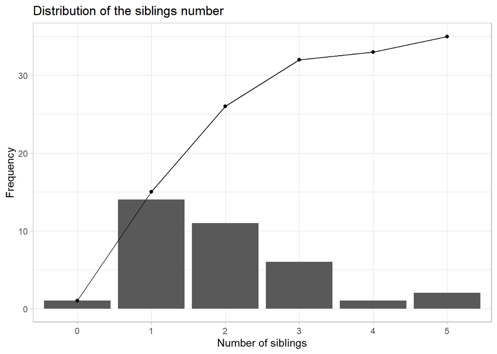

```r
# table(df_siblings)
# plot(table(df_siblings))

df_stats <- df_siblings %>%
        arrange(nb_sib) %>%
        group_by(nb_sib) %>%
        summarise(nb = n(),
                  proportion = round( nb/nrow(df_siblings) , 2 )
                  )
df_stats$cumsum_prop <- cumsum(df_stats$proportion)
df_stats$cumsum_prop_desc <- cumsum(sort(df_stats$proportion, decreasing = TRUE) )

df_stats$cumsum_nb <- cumsum(df_stats$nb)

df_stats %>%
        ggplot(aes(x = factor(nb_sib), y = nb)) +
        geom_col() +
        theme_light() +
        geom_point(aes(y = cumsum_nb)) +
        geom_line(aes(x = nb_sib +1, y = cumsum_nb) ) +
        xlab("Number of siblings") + ylab("Frequency") +
        ggtitle("Distribution of the siblings number")
```

## Exercise 5 - more stats about MSc1 students

Use the statistical data presented in the previous exercise concerning the number of brothers & sisters of students in an MSc2 class. 1. What is the mode of this series? 2. What is its average? 3. What is its median?

```r
df_siblings %>%
        summarise_all(.funs = list(
                ~mean(.),
                ~median(.)
                )
                )
```

```
## # A tibble: 1 x 2
##    mean median
##   <dbl>  <dbl>
## 1  1.94      2
```

```r
# mode
names(table(df_siblings))[table(df_siblings) == max(table(df_siblings))]
```

```
## [1] "1"
```

## Exercise 6 - random weather

You are planning a picnic today, but the morning is cloudy

50% of all rainy days start off cloudy! But cloudy mornings are common (about 40% of days start cloudy) And this is usually a dry month (only 3 of 30 days tend to be rainy, or 10%) What is the chance of rain during the day?

## Exercise 7 - dependent working lamps

Lighting a room requires the use of 2 different lamps. We note A the event “the 1st lamp has failed” and B the event “the 2nd lamp has failed”.

Tests have shown that p (A) = 0.12, P (B) = 0.18 and p (A∩B) = 0.07

Calculate :

1. - the probability of the event “at least one of the 2 lamps has failed”
2. - the probability of the “2 lamps working” event
3. - the probability of the event “the 1st lamp works and the second one fails”

## Exercise 8 - Influenza vaccination

Studies have shown that a person who has not been vaccinated against influenza has a 40% chance of contracting it while a person who has been vaccinated has a 5% risk of getting sick. The director of a company noted that each winter, a significant number of employees are absent due to the flu, decides to offer free vaccination, in order to choose the volunteers. We choose an employee at random and consider the following events: V: the employee has been vaccinated G: the employee will contract the flu during the winter

Summarize the situation with the a weighted tree :

2. Calculate the minimum percentage of people to be vaccinated so that less than 20% of employees have the flu this winter.
3. Knowing that 80% of employees agree to be vaccinated, calculate the probability that a random employee will fall ill.
4. Louis, a company engineer, fell ill. Knowing that 80% of employees have been vaccinated, calculate the probability that Louis was vaccinated.